# Segmentasi Pelanggan Toko DVD Sakila

Perbandingan Metode K-Means dan K-Medoids

Fitriyani Nur Latifah - M0724029- Kelas A

26 May 2026

# 1. Pendahuluan

**Pertanyaan Analisis:** Berdasarkan data transaksi penyewaan DVD pada database Sakila, **pelanggan seperti apa yang paling bernilai bagi bisnis?** Bisakah kita mengelompokkan pelanggan ke dalam segmen yang jelas untuk membantu pengambilan keputusan bisnis, misalnya siapa yang perlu dipertahankan dan siapa yang perlu didorong agar lebih aktif?

Tidak semua pelanggan memberikan kontribusi yang sama terhadap bisnis. Ada pelanggan yang sering menyewa dengan nilai transaksi kecil, ada yang jarang menyewa tetapi sekali menyewa nilainya besar, dan ada pula yang frekuensinya sedang namun konsisten sepanjang waktu.

Analisis segmentasi pelanggan bertujuan untuk mengelompokkan pelanggan berdasarkan kemiripan perilaku mereka, sehingga bisnis bisa merancang strategi yang lebih tepat untuk tiap kelompok.

Pada laporan ini digunakan dua metode pengelompokan (*clustering*):

- **K-Means Clustering** - metode klasik yang mengelompokkan data berdasarkan jarak ke titik pusat rata-rata
- **K-Medoids (PAM)** - metode yang lebih tahan terhadap data ekstrem, menggunakan titik data nyata sebagai pusat kelompok

Kedua metode dibandingkan menggunakan **Silhouette Score** dan analisis profil tiap kelompok untuk menentukan mana yang menghasilkan pengelompokan terbaik.

# 2. Data yang Digunakan

## 2.1 Sumber Data

Data bersumber dari database **Sakila**, yaitu contoh database resmi MySQL yang mensimulasikan sistem penyewaan DVD. Tabel yang digunakan:

| Tabel | Variabel | Keterangan |
| --- | --- | --- |
| `customer` | `customer_id` | ID unik tiap pelanggan |
| `rental` | `rental_id`, `customer_id` | Data transaksi sewa |
| `payment` | `customer_id`, `amount` | Data pembayaran |

## 2.2 Variabel Analisis

Tiga variabel yang digunakan untuk pengelompokan:

| Variabel | Nama | Keterangan |
| --- | --- | --- |
| `total_rental` | Frekuensi Sewa | Total berapa kali pelanggan menyewa |
| `total_payment` | Total Pengeluaran | Total uang yang dikeluarkan pelanggan (USD) |
| `avg_payment` | Rata-rata per Transaksi | Rata-rata nilai pembayaran per transaksi (USD) |

# 3. Persiapan Data

## 3.1 Koneksi ke Database

Koneksi ke database Sakila dilakukan menggunakan package `DBI` dan `odbc` di R.

```r
library(DBI)
library(odbc)
library(dplyr)
library(ggplot2)
library(cluster)
library(factoextra)
library(knitr)
library(kableExtra)
library(scales)
library(tidyr)
library(gridExtra)
library(corrplot)

con <- DBI::dbConnect(odbc::odbc(),
                      Driver   = "MySQL ODBC 8.0 ANSI Driver",
                      Server   = "127.0.0.1",
                      Database = "sakila",
                      UID      = "root",
                      PWD      = "Arfitria2607COMEL",
                      Port     = 3306)
```

## 3.2 Mengambil Data dengan Query SQL

Data diambil dengan menggabungkan tabel `customer`, `rental`, dan `payment` menggunakan query SQL berikut. Filter `HAVING` ditambahkan untuk memastikan hanya pelanggan dengan data transaksi yang lengkap yang diikutsertakan.

```r
query <- "
  SELECT
    c.customer_id,
    COUNT(DISTINCT r.rental_id) AS total_rental,
    SUM(p.amount)               AS total_payment,
    AVG(p.amount)               AS avg_payment
  FROM customer c
  JOIN rental  r ON c.customer_id = r.customer_id
  JOIN payment p ON c.customer_id = p.customer_id
  GROUP BY c.customer_id
  HAVING COUNT(DISTINCT r.rental_id) > 0
     AND SUM(p.amount) > 0
     AND AVG(p.amount) > 0
"

df_raw <- dbGetQuery(con, query)
dbDisconnect(con)

kable(head(df_raw, 10),
      caption = "Tabel 1. Cuplikan Data Pelanggan Sakila",
      align = "c") %>%
  kable_styling(bootstrap_options = c("striped", "hover", "condensed"))
```

Tabel 1. Cuplikan Data Pelanggan Sakila

| customer_id | total_rental | total_payment | avg_payment |
| --- | --- | --- | --- |
| 1 | 32 | 3797.76 | 3.708750 |
| 2 | 27 | 3475.71 | 4.767778 |
| 3 | 26 | 3529.24 | 5.220769 |
| 4 | 22 | 1799.16 | 3.717273 |
| 5 | 38 | 5495.56 | 3.805789 |
| 6 | 28 | 2624.16 | 3.347143 |
| 7 | 33 | 5005.11 | 4.596061 |
| 8 | 24 | 2226.24 | 3.865000 |
| 9 | 23 | 2064.71 | 3.903043 |
| 10 | 25 | 2493.75 | 3.990000 |

## 3.3 Statistik Deskriptif

Sebelum melanjutkan ke proses pengelompokan, dilakukan ringkasan statistik untuk memahami karakteristik data secara umum.

```r
df_raw <- df_raw %>%
  mutate(across(c(total_rental, total_payment, avg_payment), as.numeric))

desc_stats <- df_raw %>%
  summarise(
    across(c(total_rental, total_payment, avg_payment),
           list(Min    = min,
                Mean   = mean,
                Median = median,
                Max    = max,
                SD     = sd),
           .names = "{.col}__{.fn}")
  ) %>%
  pivot_longer(everything(),
               names_to  = c("Variabel", "Statistik"),
               names_sep = "__") %>%
  pivot_wider(names_from = Statistik, values_from = value) %>%
  mutate(across(where(is.numeric), ~round(., 2)))

kable(desc_stats,
      caption = "Tabel 2. Statistik Deskriptif Variabel Analisis",
      align   = "c") %>%
  kable_styling(bootstrap_options = c("striped", "hover"))
```

Tabel 2. Statistik Deskriptif Variabel Analisis

| Variabel | Min | Mean | Median | Max | SD |
| --- | --- | --- | --- | --- | --- |
| total_rental | 12.00 | 26.78 | 26.00 | 46.00 | 5.11 |
| total_payment | 634.56 | 3126.80 | 2943.75 | 9969.75 | 1274.90 |
| avg_payment | 2.94 | 4.20 | 4.20 | 5.70 | 0.46 |

Dari tabel di atas, terlihat bahwa variasi pada variabel `total_payment` sangat besar (SD = 1.274,90), jauh lebih besar dibandingkan `total_rental` (SD = 5,11) dan `avg_payment` (SD = 0,46). Perbedaan skala yang sangat mencolok ini bisa menyebabkan satu variabel mendominasi perhitungan jarak antar pelanggan saat proses pengelompokan. Oleh karena itu, normalisasi data wajib dilakukan terlebih dahulu agar ketiga variabel berada pada skala yang setara.

## 3.4 Exploratory Data Analysis (EDA)

Sebelum data dinormalisasi dan dimasukkan ke proses pengelompokan, dilakukan eksplorasi lebih lanjut untuk memahami distribusi tiap variabel, mengidentifikasi keberadaan data ekstrem (*outlier*), serta memeriksa hubungan antar variabel. Tahap ini penting karena temuan di sini akan menjadi dasar pertimbangan pemilihan metode pengelompokan yang paling sesuai.

### 3.4.1 Distribusi Variabel

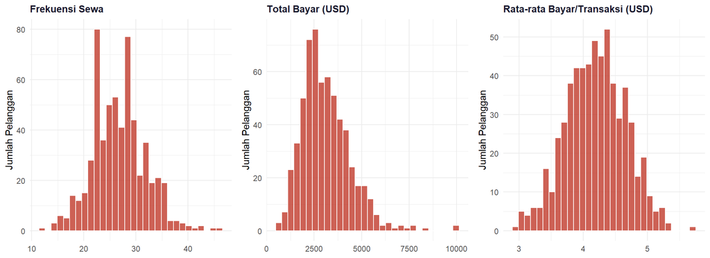

```r
vars       <- c("total_rental", "total_payment", "avg_payment")
label_vars <- c("Frekuensi Sewa", "Total Bayar (USD)", "Rata-rata Bayar/Transaksi (USD)")

plot_list <- lapply(seq_along(vars), function(i) {
  ggplot(df_raw, aes_string(x = vars[i])) +
    geom_histogram(fill = "#c0392b", color = "white", alpha = 0.8, bins = 30) +
    labs(title = label_vars[i], x = NULL, y = "Jumlah Pelanggan") +
    theme_minimal(base_size = 11) +
    theme(plot.title = element_text(face = "bold", color = "#1a1a2e", size = 11))
})

grid.arrange(grobs = plot_list, ncol = 3)
```

Histogram di atas menggambarkan sebaran nilai ketiga variabel pada seluruh pelanggan. Variabel `total_rental` menunjukkan distribusi yang cukup simetris dan mendekati normal, dengan sebagian besar pelanggan memiliki frekuensi sewa yang berkisar antara 20 hingga 35 kali. Variabel `total_payment` memiliki distribusi yang condong ke kanan (*right-skewed*), terlihat dari ekor panjang ke arah nilai yang lebih besar. Sebagian besar pelanggan memiliki total pengeluaran di bawah USD 5.000, namun terdapat sejumlah kecil pelanggan dengan total pembayaran yang jauh melampaui angka tersebut hingga mendekati USD 10.000. Kondisi ini mengisyaratkan adanya data ekstrem yang perlu diwaspadai sebelum proses pengelompokan dilakukan. Sementara itu, `avg_payment` terdistribusi relatif sempit dengan nilai yang terpusat di rentang USD 3 hingga USD 5, menandakan bahwa rata-rata harga sewa per transaksi antar pelanggan cukup seragam dan tidak terlalu bervariasi.

### 3.4.2 Deteksi Outlier

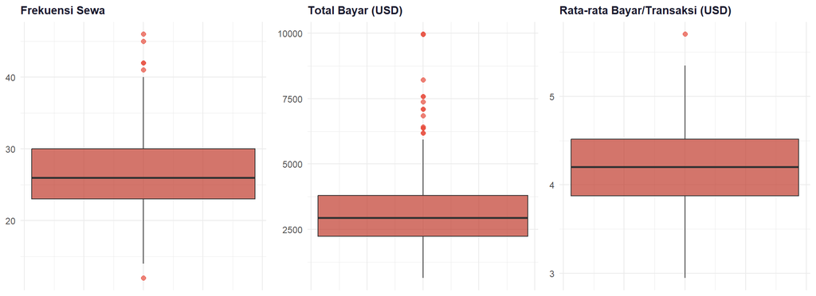

```r
plot_box <- lapply(seq_along(vars), function(i) {
  ggplot(df_raw, aes_string(y = vars[i])) +
    geom_boxplot(fill = "#c0392b", alpha = 0.7, outlier.color = "#e74c3c",
                 outlier.size = 2) +
    labs(title = label_vars[i], x = NULL, y = NULL) +
    theme_minimal(base_size = 11) +
    theme(plot.title  = element_text(face = "bold", color = "#1a1a2e", size = 11),
          axis.text.x = element_blank())
})

grid.arrange(grobs = plot_box, ncol = 3)
```

```r
outlier_summary <- sapply(vars, function(v) {
  x   <- df_raw[[v]]
  q1  <- quantile(x, 0.25)
  q3  <- quantile(x, 0.75)
  iqr <- q3 - q1
  sum(x < (q1 - 1.5 * iqr) | x > (q3 + 1.5 * iqr))
})

tbl_outlier <- data.frame(
  Variabel       = label_vars,
  Jumlah_Outlier = as.integer(outlier_summary),
  Persen         = paste0(round(outlier_summary / nrow(df_raw) * 100, 1), "%")
)

kable(tbl_outlier,
      col.names = c("Variabel", "Jumlah Outlier", "Persentase"),
      caption   = "Tabel 3. Jumlah Outlier per Variabel (Metode IQR)",
      align     = "c") %>%
  kable_styling(bootstrap_options = c("striped", "hover"))
```

Tabel 3. Jumlah Outlier per Variabel (Metode IQR)

| Variabel | Jumlah Outlier | Persentase |
| --- | --- | --- |
| Frekuensi Sewa | 6 | 1% |
| Total Bayar (USD) | 14 | 2.3% |
| Rata-rata Bayar/Transaksi (USD) | 1 | 0.2% |

Boxplot dan tabel di atas memperlihatkan bahwa variabel `total_payment` memiliki jumlah outlier terbanyak, yaitu 14 data (2,3% dari total pelanggan). Titik-titik merah yang tampak jauh di atas whisker atas pada boxplot mengonfirmasi keberadaan pelanggan dengan total pengeluaran yang jauh melampaui mayoritas. Variabel `total_rental` menyusul dengan 6 outlier (1%), sedangkan `avg_payment` hanya memiliki 1 outlier (0,2%), yang artinya rata-rata nilai transaksi per pelanggan hampir tidak memiliki nilai ekstrem. Temuan ini menjadi pertimbangan penting dalam pemilihan metode pengelompokan: K-Means yang berbasis rata-rata rentan terseret oleh nilai-nilai ekstrem pada `total_payment`, sehingga **K-Medoids yang menggunakan titik data nyata sebagai pusat kelompok lebih tepat digunakan** pada data ini.

### 3.4.3 Analisis Korelasi Antar Variabel

Selain distribusi dan outlier, penting pula untuk memeriksa sejauh mana ketiga variabel saling berkaitan. Variabel yang berkorelasi sangat tinggi pada dasarnya mengukur hal yang hampir sama, sehingga keberadaan keduanya secara bersamaan dalam proses pengelompokan bisa memberikan bobot yang tidak proporsional pada satu dimensi tertentu.

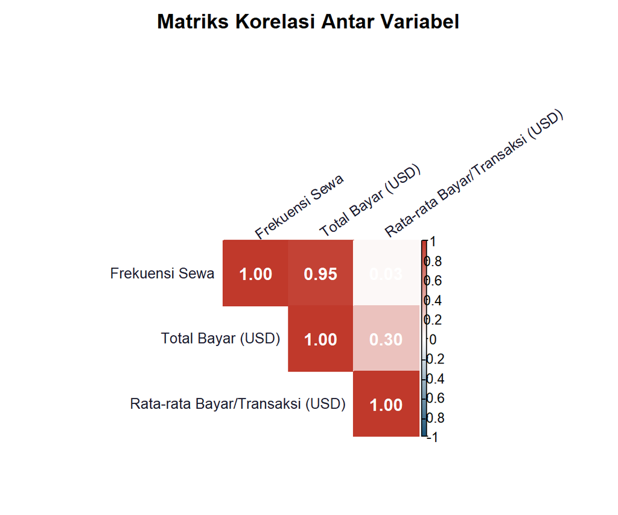

```r
mat_cor <- cor(df_raw[, vars])
rownames(mat_cor) <- label_vars
colnames(mat_cor) <- label_vars

corrplot(mat_cor,
         method      = "color",
         type        = "upper",
         addCoef.col = "white",
         tl.col      = "#1a1a2e",
         tl.srt      = 35,
         tl.cex      = 0.85,
         col         = colorRampPalette(c("#1a5276", "white", "#c0392b"))(200),
         title       = "Matriks Korelasi Antar Variabel",
         mar         = c(0, 0, 2, 0))
```

```r
cor_df <- as.data.frame(round(mat_cor, 3))
kable(cor_df,
      caption = "Tabel 4. Matriks Korelasi Antar Variabel",
      align   = "c") %>%
  kable_styling(bootstrap_options = c("striped", "hover"))
```

Tabel 4. Matriks Korelasi Antar Variabel

|  | Frekuensi Sewa | Total Bayar (USD) | Rata-rata Bayar/Transaksi (USD) |
| --- | --- | --- | --- |
| Frekuensi Sewa | 1.000 | 0.945 | 0.031 |
| Total Bayar (USD) | 0.945 | 1.000 | 0.301 |
| Rata-rata Bayar/Transaksi (USD) | 0.031 | 0.301 | 1.000 |

Dari matriks korelasi di atas, terlihat bahwa `total_rental` dan `total_payment` memiliki korelasi yang sangat tinggi, yaitu sebesar 0,945. Angka ini mendekati 1, yang berarti kedua variabel bergerak hampir secara bersamaan: semakin sering pelanggan menyewa, semakin besar pula total yang mereka bayarkan. Tingginya korelasi ini menunjukkan bahwa kedua variabel membawa informasi yang sangat serupa ke dalam proses pengelompokan.

Sebaliknya, `avg_payment` menunjukkan korelasi yang jauh lebih rendah terhadap `total_rental` (0,031) maupun `total_payment` (0,301). Korelasi yang sangat lemah dengan `total_rental` menunjukkan bahwa frekuensi sewa tidak menentukan seberapa mahal pilihan film seorang pelanggan. Adapun korelasi moderat dengan `total_payment` (0,301) cukup masuk akal karena pelanggan yang memilih film dengan harga lebih tinggi memang akan berkontribusi lebih besar pada total pengeluaran, meski pengaruhnya tidak dominan.

Dengan demikian, ketiga variabel ini tetap dipertahankan dalam proses pengelompokan karena masing-masing membawa informasi yang saling melengkapi. Korelasi tinggi antara `total_rental` dan `total_payment` bukan menjadi alasan untuk menghapus salah satunya, melainkan menjadi pengingat bahwa interpretasi hasil harus mempertimbangkan keterkaitan antara keduanya.

## 3.5 Normalisasi Data

Data dinormalisasi menggunakan metode **Z-score** agar semua variabel berada pada skala yang sama sebelum dikelompokkan:

$$z_i = \frac{x_i -
\bar{x}}{s}$$

di mana $x_i$ adalah nilai data, $\bar{x}$ adalah rata-rata, dan $s$ adalah standar deviasi.

```r
df_clean <- df_raw %>%
  filter(
    is.finite(total_rental),
    is.finite(total_payment),
    is.finite(avg_payment)
  )

df_scaled <- df_clean %>%
  select(total_rental, total_payment, avg_payment) %>%
  scale() %>%
  as.data.frame()

rownames(df_scaled) <- df_clean$customer_id
df_raw <- df_clean

cat("Data siap:", nrow(df_scaled), "pelanggan,", ncol(df_scaled), "variabel\n")
```

```
## Data siap: 599 pelanggan, 3 variabel
```

```r
cat("Jumlah NA:", sum(is.na(df_scaled)),
    "| Jumlah Inf:", sum(sapply(df_scaled, function(x) sum(is.infinite(x)))), "\n")
```

```
## Jumlah NA: 0 | Jumlah Inf: 0
```

Output di atas mengonfirmasi bahwa data sudah bersih: terdapat 599 pelanggan dengan 3 variabel, tidak ada nilai kosong (NA) maupun nilai tak terhingga (Inf). Data siap untuk masuk ke tahap pengelompokan.

# 4. Penentuan Jumlah Kelompok Optimal

Sebelum proses pengelompokan dijalankan, perlu ditentukan terlebih dahulu berapa jumlah kelompok ($k$) yang paling sesuai. Dua metode digunakan:

## 4.1 Elbow Method

Metode ini melihat nilai **Total Within-Cluster Sum of Squares (WSS)**, yaitu total jarak semua titik data ke pusat kelompoknya masing-masing. Semakin banyak kelompok, nilai WSS akan semakin kecil. Titik di mana penurunan WSS mulai melambat dan membentuk “siku” adalah nilai $k$ yang disarankan.

$$WSS = \sum_{k=1}^{K} \sum_{x_i \in C_k}
\|x_i - \mu_k\|^2$$

di mana $\mu_k$ adalah pusat dari kelompok ke-$k$.

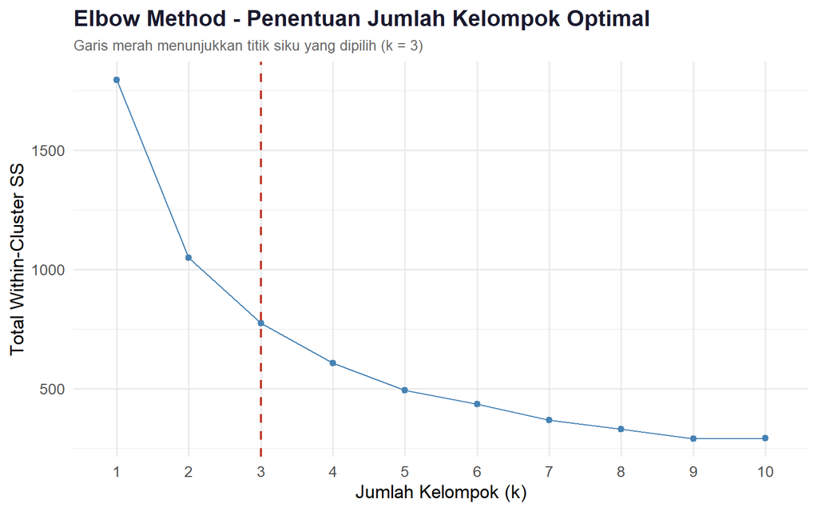

```r
set.seed(123)

fviz_nbclust(df_scaled, kmeans, method = "wss", k.max = 10) +
  geom_vline(xintercept = 3, linetype = "dashed", color = "#c0392b", linewidth = 0.8) +
  labs(
    title    = "Elbow Method - Penentuan Jumlah Kelompok Optimal",
    subtitle = "Garis merah menunjukkan titik siku yang dipilih (k = 3)",
    x        = "Jumlah Kelompok (k)",
    y        = "Total Within-Cluster SS"
  ) +
  theme_minimal(base_size = 13) +
  theme(
    plot.title    = element_text(face = "bold", color = "#1a1a2e"),
    plot.subtitle = element_text(color = "#666", size = 10)
  )
```

## 4.2 Silhouette Method

Metode ini mengukur seberapa pas suatu data berada di dalam kelompoknya dibandingkan kelompok lain. Semakin tinggi nilai rata-rata Silhouette, semakin baik pengelompokan yang terbentuk.

$$s(i) = \frac{b(i) - a(i)}{\max\{a(i),\
b(i)\}}$$

di mana $a(i)$ adalah rata-rata jarak ke sesama anggota kelompok, dan $b(i)$ adalah rata-rata jarak ke anggota kelompok lain yang paling dekat.

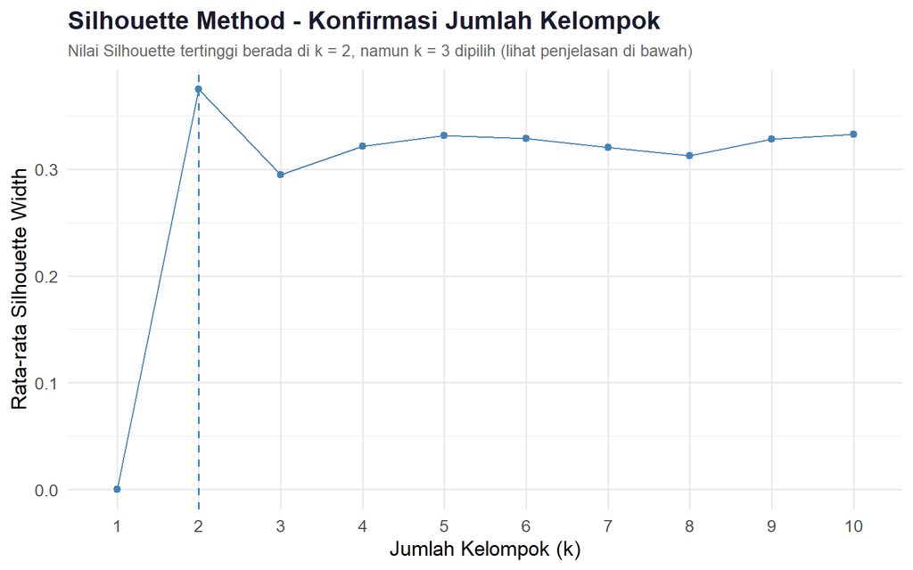

```r
set.seed(123)

fviz_nbclust(df_scaled, kmeans, method = "silhouette", k.max = 10) +
  labs(
    title    = "Silhouette Method - Konfirmasi Jumlah Kelompok",
    subtitle = "Nilai Silhouette tertinggi berada di k = 2, namun k = 3 dipilih (lihat penjelasan di bawah)",
    x        = "Jumlah Kelompok (k)",
    y        = "Rata-rata Silhouette Width"
  ) +
  theme_minimal(base_size = 13) +
  theme(
    plot.title    = element_text(face = "bold", color = "#1a1a2e"),
    plot.subtitle = element_text(color = "#666", size = 10)
  )
```

**Keputusan - dipilih k=3:** Meskipun Silhouette Method menunjukkan nilai tertinggi di k=2, dipilih k=3 karena dua alasan utama. Pertama, Elbow Method secara konsisten menunjukkan k=3 sebagai titik yang paling efisien. Kedua, k=2 hanya menghasilkan dua kelompok yang terlalu umum dan kurang berguna dari sisi bisnis. Dengan k=3, terbentuk tiga segmen pelanggan yang berbeda karakternya dan bisa langsung ditindaklanjuti dengan strategi yang berbeda pula.

# 5. K-Means Clustering

## 5.1 Cara Kerja K-Means

K-Means bekerja dengan langkah-langkah berikut:

1. Pilih $k$ titik pusat awal secara acak
2. Setiap data dimasukkan ke kelompok dengan pusat yang paling dekat
3. Pusat kelompok diperbarui dengan menghitung rata-rata semua anggotanya
4. Langkah 2 dan 3 diulang sampai tidak ada perpindahan data antar kelompok

Tujuan K-Means adalah meminimalkan total jarak antara setiap data dan pusat kelompoknya:

$$J = \sum_{k=1}^{K} \sum_{x_i \in C_k}
\|x_i - \mu_k\|^2$$

Kekurangan K-Means: karena menggunakan rata-rata sebagai pusat kelompok, metode ini bisa terpengaruh oleh data yang nilainya sangat ekstrem.

## 5.2 Hasil K-Means

```r
set.seed(42)
km_result <- kmeans(df_scaled, centers = 3, nstart = 25)
df_raw$cluster_kmeans <- as.factor(km_result$cluster)
```

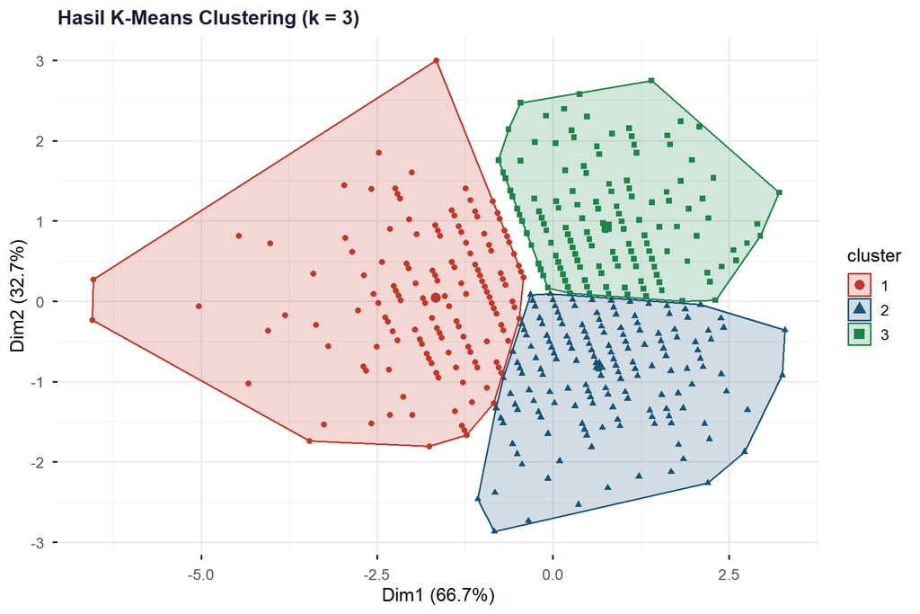

```r
fviz_cluster(km_result, data = df_scaled,
             palette      = c("#c0392b", "#1a5276", "#1e8449"),
             geom         = "point",
             ellipse.type = "convex",
             ggtheme      = theme_minimal(base_size = 13),
             main         = "Hasil K-Means Clustering (k = 3)") +
  theme(plot.title = element_text(face = "bold", color = "#1a1a2e", size = 14))
```

Grafik di atas menampilkan hasil pengelompokan K-Means dalam dua dimensi utama (Dim1 dan Dim2) yang menjelaskan sekitar 66,7% dan 32,7% dari keragaman data. Terlihat tiga kelompok yang terbentuk dengan cukup jelas: Kelompok 1 (merah) berada di sisi kiri grafik, Kelompok 2 (biru) di bagian bawah kanan, dan Kelompok 3 (hijau) di bagian atas kanan. Terdapat sedikit tumpang tindih antara Kelompok 2 dan Kelompok 3 di area tengah, yang menunjukkan bahwa batas antara dua kelompok tersebut tidak sepenuhnya tegas.

## 5.3 Profil Kelompok K-Means

```r
profil_km <- df_raw %>%
  group_by(cluster_kmeans) %>%
  summarise(
    Jumlah_Pelanggan = n(),
    Rata_Sewa        = round(mean(total_rental), 1),
    Rata_Total_Bayar = round(mean(total_payment), 2),
    Rata_Avg_Bayar   = round(mean(avg_payment), 2)
  )

kable(profil_km,
      col.names = c("Kelompok", "Jml. Pelanggan", "Rata-rata Sewa",
                    "Rata-rata Total Bayar (USD)", "Rata-rata Bayar/Transaksi (USD)"),
      caption   = "Tabel 5. Profil Kelompok K-Means",
      align     = "c") %>%
  kable_styling(bootstrap_options = c("striped", "hover"))
```

Tabel 5. Profil Kelompok K-Means

| Kelompok | Jml. Pelanggan | Rata-rata Sewa | Rata-rata Total Bayar (USD) | Rata-rata Bayar/Transaksi (USD) |
| --- | --- | --- | --- | --- |
| 1 | 178 | 32.4 | 4640.19 | 4.40 |
| 2 | 230 | 25.8 | 2561.06 | 3.77 |
| 3 | 191 | 22.8 | 2397.67 | 4.53 |

Dari tabel profil K-Means di atas, terlihat perbedaan karakteristik yang cukup jelas antar kelompok. Kelompok 1 adalah kelompok dengan frekuensi sewa dan total pengeluaran tertinggi (32,4 kali dan USD 4.640,19), sedangkan Kelompok 2 memiliki frekuensi sewa menengah (25,8 kali) dengan rata-rata bayar per transaksi terendah (USD 3,77). Kelompok 3 memiliki frekuensi sewa terendah (22,8 kali) namun rata-rata bayar per transaksinya justru paling tinggi (USD 4,53), mengindikasikan pelanggan yang jarang menyewa tetapi memilih film dengan harga lebih mahal.

# 6. K-Medoids (PAM) Clustering

## 6.1 Cara Kerja K-Medoids

Berbeda dengan K-Means yang menggunakan rata-rata sebagai pusat kelompok, **K-Medoids** menggunakan salah satu titik data nyata yang paling mewakili kelompoknya (disebut *medoid*). Karena pusat kelompoknya adalah data asli, metode ini tidak mudah terpengaruh oleh nilai yang sangat ekstrem.

Tujuan K-Medoids adalah meminimalkan total jarak antara setiap data dan medoid kelompoknya:

$$\text{minimize} \sum_{k=1}^{K} \sum_{x_i
\in C_k} d(x_i,\ m_k)$$

di mana $m_k$ adalah medoid dari kelompok ke-$k$ dan $d(\cdot)$ adalah jarak Euclidean.

## 6.2 Hasil K-Medoids

```r
set.seed(42)
pam_result <- pam(df_scaled, k = 3)
df_raw$cluster_pam <- as.factor(pam_result$clustering)
```

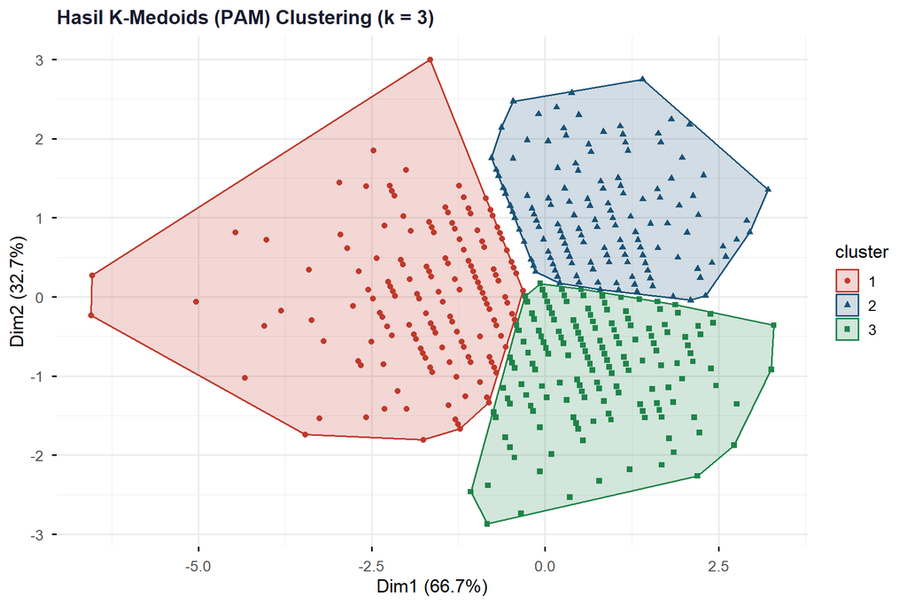

```r
fviz_cluster(pam_result, data = df_scaled,
             palette      = c("#c0392b", "#1a5276", "#1e8449"),
             geom         = "point",
             ellipse.type = "convex",
             ggtheme      = theme_minimal(base_size = 13),
             main         = "Hasil K-Medoids (PAM) Clustering (k = 3)") +
  theme(plot.title = element_text(face = "bold", color = "#1a1a2e", size = 14))
```

Hasil pengelompokan K-Medoids secara visual mirip dengan K-Means, dengan tiga kelompok yang terbentuk di posisi yang serupa. Namun jika diperhatikan, batas antar kelompok pada K-Medoids terlihat sedikit lebih rapi, terutama di area tumpang tindih antara kelompok biru dan hijau. Ini konsisten dengan sifat K-Medoids yang lebih stabil karena pusat kelompoknya tidak dipengaruhi oleh nilai ekstrem.

## 6.3 Profil Kelompok K-Medoids

```r
profil_pam <- df_raw %>%
  group_by(cluster_pam) %>%
  summarise(
    Jumlah_Pelanggan = n(),
    Rata_Sewa        = round(mean(total_rental), 1),
    Rata_Total_Bayar = round(mean(total_payment), 2),
    Rata_Avg_Bayar   = round(mean(avg_payment), 2)
  )

kable(profil_pam,
      col.names = c("Kelompok", "Jml. Pelanggan", "Rata-rata Sewa",
                    "Rata-rata Total Bayar (USD)", "Rata-rata Bayar/Transaksi (USD)"),
      caption   = "Tabel 6. Profil Kelompok K-Medoids",
      align     = "c") %>%
  kable_styling(bootstrap_options = c("striped", "hover"))
```

Tabel 6. Profil Kelompok K-Medoids

| Kelompok | Jml. Pelanggan | Rata-rata Sewa | Rata-rata Total Bayar (USD) | Rata-rata Bayar/Transaksi (USD) |
| --- | --- | --- | --- | --- |
| 1 | 185 | 32.3 | 4601.43 | 4.38 |
| 2 | 189 | 22.7 | 2385.08 | 4.53 |
| 3 | 225 | 25.7 | 2537.36 | 3.77 |

Profil kelompok K-Medoids menghasilkan pola yang sangat mirip dengan K-Means. Kelompok 1 tetap menjadi kelompok dengan frekuensi sewa dan total pengeluaran tertinggi (32,3 kali dan USD 4.601,43). Kelompok 2 memiliki frekuensi sewa terendah namun rata-rata bayar per transaksinya paling tinggi (USD 4,53). Kelompok 3 adalah kelompok terbesar (225 pelanggan) dengan karakteristik menengah. Perbedaan kecil dengan K-Means terlihat pada jumlah anggota tiap kelompok, yang sedikit bergeser karena K-Medoids menggunakan titik data nyata sebagai pusat kelompok.

# 7. Perbandingan dan Evaluasi

## 7.1 Silhouette Score

Silhouette Score digunakan untuk mengevaluasi seberapa baik kualitas pengelompokan yang dihasilkan. Nilai mendekati **+1** berarti data sudah berada di kelompok yang tepat, nilai mendekati **0** berarti data berada di batas antara dua kelompok, dan nilai **negatif** berarti data mungkin salah kelompok.

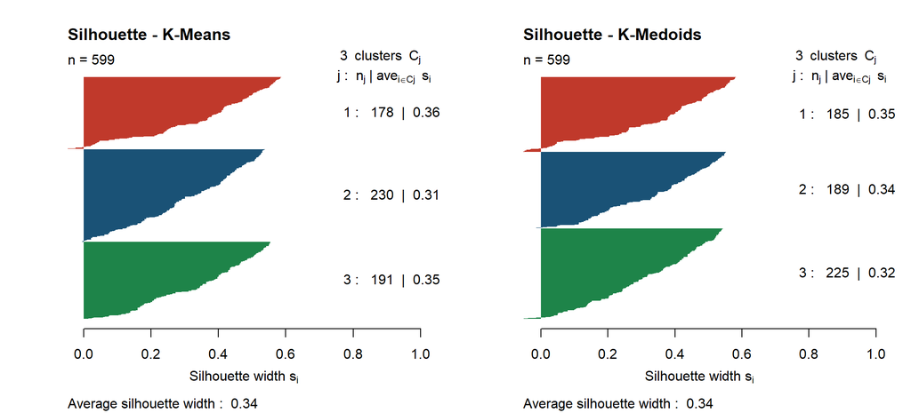

```r
sil_km  <- silhouette(km_result$cluster,     dist(df_scaled))
sil_pam <- silhouette(pam_result$clustering, dist(df_scaled))

par(mfrow = c(1, 2))
plot(sil_km,  col = c("#c0392b", "#1a5276", "#1e8449"),
     main = "Silhouette - K-Means", border = NA)
plot(sil_pam, col = c("#c0392b", "#1a5276", "#1e8449"),
     main = "Silhouette - K-Medoids", border = NA)
```

```r
par(mfrow = c(1, 1))
```

Dari kedua grafik Silhouette di atas, terlihat bahwa sebagian besar data pada kedua metode memiliki nilai Silhouette positif, yang artinya pengelompokan secara umum sudah cukup baik. Namun terdapat sejumlah kecil data dengan nilai mendekati nol atau sedikit negatif, yang menunjukkan bahwa beberapa pelanggan berada di perbatasan antara dua kelompok dan bisa saja masuk ke kelompok mana pun. Ini wajar mengingat perilaku pelanggan di dunia nyata memang jarang terpisah secara sempurna.

```r
skor_km  <- round(mean(sil_km[, 3]),  4)
skor_pam <- round(mean(sil_pam[, 3]), 4)

sil_km_per  <- tapply(sil_km[, 3],  sil_km[, 1],  mean)
sil_pam_per <- tapply(sil_pam[, 3], sil_pam[, 1], mean)

hasil_eval <- data.frame(
  Metode         = c("K-Means", "K-Medoids (PAM)"),
  Sil_Rata2      = c(skor_km, skor_pam),
  Sil_Cluster1   = c(round(sil_km_per[1], 4), round(sil_pam_per[1], 4)),
  Sil_Cluster2   = c(round(sil_km_per[2], 4), round(sil_pam_per[2], 4)),
  Sil_Cluster3   = c(round(sil_km_per[3], 4), round(sil_pam_per[3], 4)),
  Sil_Terendah   = c(round(min(sil_km_per), 4), round(min(sil_pam_per), 4)),
  Catatan        = c(
    ifelse(skor_km > skor_pam, "Skor rata-rata lebih tinggi", ""),
    ifelse(skor_pam > skor_km, "Skor rata-rata lebih tinggi", "Skor per kelompok lebih merata")
  )
)

kable(hasil_eval,
      col.names = c("Metode", "Sil. Rata-rata", "Sil. K1",
                    "Sil. K2", "Sil. K3", "Sil. Terendah", "Catatan"),
      caption   = "Tabel 7. Perbandingan Evaluasi K-Means dan K-Medoids",
      align     = "c") %>%
  kable_styling(bootstrap_options = c("striped", "hover"))
```

Tabel 7. Perbandingan Evaluasi K-Means dan K-Medoids

| Metode | Sil. Rata-rata | Sil. K1 | Sil. K2 | Sil. K3 | Sil. Terendah | Catatan |
| --- | --- | --- | --- | --- | --- | --- |
| K-Means | 0.3376 | 0.3570 | 0.3128 | 0.3494 | 0.3128 | Skor rata-rata lebih tinggi |
| K-Medoids (PAM) | 0.3369 | 0.3476 | 0.3447 | 0.3216 | 0.3216 | Skor per kelompok lebih merata |

Dari tabel perbandingan di atas, baik K-Means maupun K-Medoids menghasilkan nilai Silhouette rata-rata yang identik, yaitu sebesar **0,34**. Meskipun secara keseluruhan skornya setara, terdapat perbedaan yang lebih berarti ketika dilihat per kelompok. Pada K-Means, Kelompok 2 memiliki nilai Silhouette terendah sebesar 0,31, yang menunjukkan bahwa sebagian anggota kelompok ini berada cukup dekat dengan batas kelompok lain. Pada K-Medoids, nilai terendah ada di Kelompok 3 dengan skor 0,32, sedikit lebih tinggi dibanding kelompok terlemah pada K-Means. Artinya, K-Medoids menghasilkan distribusi kualitas yang lebih merata di antara ketiga kelompok, tanpa ada satu kelompok yang kualitasnya tertinggal secara mencolok.

## 7.2 Perbandingan Profil Kelompok (K-Medoids)

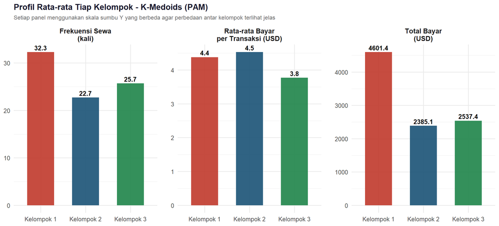

```r
profil_long <- profil_pam %>%
  pivot_longer(cols = c(Rata_Sewa, Rata_Total_Bayar, Rata_Avg_Bayar),
               names_to  = "Variabel",
               values_to = "Nilai") %>%
  mutate(
    Variabel = recode(Variabel,
      "Rata_Sewa"        = "Frekuensi Sewa\n(kali)",
      "Rata_Total_Bayar" = "Total Bayar\n(USD)",
      "Rata_Avg_Bayar"   = "Rata-rata Bayar\nper Transaksi (USD)"
    ),
    Cluster_Label = paste("Kelompok", cluster_pam)
  )

ggplot(profil_long, aes(x = Cluster_Label, y = Nilai, fill = cluster_pam)) +
  geom_col(width = 0.6, alpha = 0.9) +
  geom_text(aes(label = round(Nilai, 1)), vjust = -0.4, size = 3.5, fontface = "bold") +
  scale_fill_manual(values = c("#c0392b", "#1a5276", "#1e8449"), guide = "none") +
  facet_wrap(~ Variabel, scales = "free_y", nrow = 1) +
  labs(
    title    = "Profil Rata-rata Tiap Kelompok - K-Medoids (PAM)",
    subtitle = "Setiap panel menggunakan skala sumbu Y yang berbeda agar perbedaan antar kelompok terlihat jelas",
    x        = NULL,
    y        = NULL
  ) +
  theme_minimal(base_size = 12) +
  theme(
    plot.title    = element_text(face = "bold", color = "#1a1a2e", size = 13),
    plot.subtitle = element_text(color = "#666", size = 9),
    strip.text    = element_text(face = "bold", size = 11),
    panel.spacing = unit(1.5, "lines")
  )
```

Grafik profil di atas memperlihatkan perbedaan karakteristik ketiga kelompok secara lebih jelas. Pada panel frekuensi sewa, Kelompok 1 jauh lebih tinggi (32,3 kali) dibanding Kelompok 2 (22,7 kali) dan Kelompok 3 (25,7 kali). Pada panel total bayar, Kelompok 1 juga mendominasi dengan rata-rata USD 4.601, hampir dua kali lipat dari Kelompok 2 (USD 2.385) maupun Kelompok 3 (USD 2.537). Yang menarik, pada panel rata-rata bayar per transaksi, justru Kelompok 2 yang paling tinggi (USD 4,53), meskipun frekuensi sewanya paling rendah. Ini menunjukkan bahwa Kelompok 2 memiliki pola yang berbeda: jarang menyewa tapi memilih film yang lebih mahal.

# 8. Interpretasi Hasil

## Profil Tiap Kelompok Pelanggan

Berdasarkan hasil analisis menggunakan K-Medoids (Tabel 6 dan grafik profil), terbentuk tiga kelompok pelanggan dengan karakteristik sebagai berikut:

**Kelompok 1 - Pelanggan Aktif (185 pelanggan)** Kelompok ini memiliki frekuensi sewa tertinggi (rata-rata 32,3 kali) dan total pengeluaran terbesar (rata-rata USD 4.601,43). Rata-rata pembayaran per transaksi sebesar USD 4,38, yang berarti nilai tinggi mereka berasal dari seringnya mereka menyewa, bukan dari harga sewa per film yang mahal. Kelompok ini adalah pelanggan paling berharga bagi bisnis dan perlu dijaga dengan baik. Strategi yang tepat antara lain program loyalitas, akses lebih awal ke film baru, atau layanan prioritas.

**Kelompok 2 - Pelanggan Selektif (189 pelanggan)** Kelompok ini memiliki frekuensi sewa terendah (rata-rata 22,7 kali), namun rata-rata pembayaran per transaksinya justru paling tinggi (USD 4,53). Ini menunjukkan bahwa pelanggan di kelompok ini jarang menyewa tetapi cenderung memilih film dengan harga sewa lebih mahal, kemungkinan film terbaru atau film dalam kategori premium. Potensi kelompok ini sangat besar: jika frekuensi sewanya bisa ditingkatkan, kontribusi totalnya bisa mendekati bahkan melampaui Kelompok 1. Strategi yang sesuai adalah rekomendasi film yang disesuaikan dan promosi khusus untuk mendorong kunjungan lebih sering.

**Kelompok 3 - Pelanggan Reguler (225 pelanggan)** Kelompok terbesar dengan 225 anggota. Frekuensi sewa dan total pengeluarannya berada di level menengah (25,7 kali, USD 2.537,36), dengan rata-rata bayar per transaksi terendah (USD 3,77). Kelompok ini adalah basis pelanggan yang stabil dan konsisten. Strategi yang tepat adalah program bundling atau promosi sewa ke-N gratis untuk mendorong peningkatan frekuensi kunjungan sekaligus nilai transaksinya.

## Perbandingan K-Means dan K-Medoids

Berdasarkan Tabel 7, K-Means dan K-Medoids menghasilkan nilai Silhouette rata-rata yang sama, yaitu **0,34**. Dengan demikian, dari sisi skor keseluruhan, keduanya berada di tingkat yang setara.

Perbedaan yang lebih relevan terlihat pada distribusi nilai Silhouette per kelompok. Pada K-Means, Kelompok 2 memiliki skor terendah sebesar 0,31, yang berarti anggota kelompok ini relatif kurang kompak dibanding kelompok lainnya. Pada K-Medoids, nilai terendah berada di Kelompok 3 dengan skor 0,32, lebih tinggi dibanding kelompok terlemah K-Means. Ini menunjukkan bahwa K-Medoids menghasilkan pengelompokan yang lebih konsisten di setiap segmen, tanpa ada satu kelompok pun yang kualitasnya jauh tertinggal.

Selain itu, K-Medoids menggunakan titik data nyata sebagai pusat kelompok, bukan rata-rata. Ini membuatnya lebih stabil ketika ada pelanggan dengan pola yang sangat berbeda dari rata-rata, yang memang bisa terjadi pada data transaksi seperti ini.

Dengan mempertimbangkan kemerataan kualitas per kelompok dan stabilitasnya, **K-Medoids dipilih sebagai metode yang lebih sesuai** untuk data ini.

# 9. Implikasi Bisnis

Hasil segmentasi ini bukan sekadar pengelompokan data. Setiap kelompok yang terbentuk membawa pesan yang berbeda bagi bisnis dan seharusnya ditindaklanjuti dengan cara yang berbeda pula.

**Kelompok 1 - Pelanggan Aktif: Pertahankan dengan Baik**

Kelompok ini hanya terdiri dari 185 orang (sekitar 31% dari total pelanggan), namun kontribusi rata-rata per orangnya jauh di atas kelompok lain, yaitu USD 4.601 per pelanggan. Kehilangan satu pelanggan dari kelompok ini setara dengan kehilangan hampir dua pelanggan dari kelompok lain.

Bisnis perlu memastikan pengalaman mereka selalu memuaskan. Program loyalitas seperti kartu member, poin reward, atau akses lebih awal ke film baru bisa menjadi cara untuk membuat mereka tetap aktif dan merasa dihargai.

**Kelompok 2 - Pelanggan Selektif: Dorong Frekuensinya**

Kelompok ini adalah yang paling menarik secara strategis. Mereka sudah terbukti bersedia membayar lebih mahal per transaksi (USD 4,53), artinya daya beli mereka ada. Masalahnya hanya satu: mereka jarang datang.

Jika bisnis bisa mendorong frekuensi kunjungan kelompok ini dari 22,7 kali menjadi setara Kelompok 1 (32 kali) saja, dengan rata-rata bayar yang sama, total kontribusi mereka bisa melampaui Kelompok 1. Ini adalah peluang pertumbuhan yang paling realistis.

Cara yang bisa dicoba: kirimkan rekomendasi film baru yang sesuai dengan riwayat sewa mereka, tawarkan promo “beli 2 gratis 1” untuk mendorong kunjungan tambahan, atau ingatkan mereka ketika ada film dalam kategori yang biasa mereka sewa sudah tersedia.

**Kelompok 3 - Pelanggan Reguler: Tingkatkan Nilai Transaksinya**

Kelompok ini adalah yang terbesar (225 orang) dan paling stabil. Mereka rutin datang, hanya saja nilai per transaksinya paling rendah (USD 3,77). Strategi yang tepat bukan untuk membuat mereka datang lebih sering, karena frekuensinya sudah cukup baik, melainkan mendorong mereka untuk memilih film dengan harga sewa yang sedikit lebih tinggi.

Program bundling seperti “sewa 3 film sekaligus dengan harga khusus” atau rekomendasi film premium yang relevan bisa membantu meningkatkan nilai rata-rata transaksi mereka secara bertahap.

# 10. Kesimpulan

Pertanyaan awal dalam analisis ini adalah: **pelanggan seperti apa yang paling bernilai bagi bisnis, dan bisakah kita mengelompokkan mereka secara bermakna?**

Jawabannya: **ya, dan hasilnya langsung bisa digunakan.**

Dengan menggunakan metode K-Medoids pada data transaksi 599 pelanggan dari database Sakila, terbentuk tiga kelompok pelanggan yang masing-masing memiliki karakter dan potensi yang berbeda. K-Medoids dipilih dibanding K-Means karena menghasilkan distribusi kualitas pengelompokan yang lebih merata di setiap kelompok, meskipun secara nilai Silhouette rata-rata keduanya menghasilkan angka yang sama, yaitu 0,34.

Temuan utama dari analisis ini:

1. **Pelanggan Aktif (Kelompok 1)** adalah yang paling berharga saat ini dan harus diprioritaskan untuk dipertahankan melalui program loyalitas.
2. **Pelanggan Selektif (Kelompok 2)** adalah peluang pertumbuhan terbesar karena daya beli mereka sudah terbukti tinggi, hanya perlu didorong agar lebih sering datang.
3. **Pelanggan Reguler (Kelompok 3)** adalah fondasi bisnis yang stabil dan bisa ditingkatkan nilai transaksinya secara bertahap melalui program bundling dan rekomendasi yang tepat.

Segmentasi ini memberikan gambaran yang jelas bahwa tidak semua pelanggan perlu diperlakukan dengan cara yang sama. Bisnis yang mampu memperlakukan setiap segmen sesuai karakternya akan jauh lebih efisien dalam mengalokasikan sumber daya dan memaksimalkan pendapatan.